# Linear Statistical Analysis

A little about the data. In this project we have the “Denver Neighborhoods” data where we have information from 44 different neighborhoods in Denver.

Information that we have: X1 - total population (in 1000s) X2 - percentage of changes in population X3 - percentage of children (under age of 18) in the population X4 - number of schools that have free lunch X5 - percentage of changes in the household’s income X6 - crime rate X7 - percentage of changes in crime rate

The task is to find the best linear statistical model for predicting percentage of children in population .

```r
# install.packages("xlsx")
library(xlsx)
mine_data <- read.xlsx("Denver_Neighborhoods.xlsx", 1, header = TRUE)
```

```r
head(mine_data)
```

|  | X1 | X2 | X3 | X4 | X5 | X6 | X7 |
| --- | --- | --- | --- | --- | --- | --- | --- |
| 1 | 6.9 | 1.8 | 30.2 | 58.3 | 27.3 | 84.9 | -14.2 |
| 2 | 8.4 | 28.5 | 38.8 | 87.5 | 39.8 | 172.6 | -34.1 |
| 3 | 5.7 | 7.8 | 31.7 | 83.5 | 26.0 | 154.2 | -15.8 |
| 4 | 7.4 | 2.3 | 24.2 | 14.2 | 29.4 | 35.2 | -13.9 |
| 5 | 8.5 | -0.7 | 28.1 | 46.7 | 26.6 | 69.2 | -13.9 |
| 6 | 13.8 | 7.2 | 10.4 | 57.9 | 26.2 | 111.0 | -22.6 |

```r
attach(mine_data)
summary(mine_data)
```

```
       X1               X2               X3              X4              X5              X6               X7
 Min.   : 1.700   Min.   :-3.300   Min.   : 7.50   Min.   : 5.70   Min.   :11.70   Min.   : 27.10   Min.   :-45.600
 1st Qu.: 4.175   1st Qu.: 1.975   1st Qu.:20.62   1st Qu.:29.60   1st Qu.:23.65   1st Qu.: 62.33   1st Qu.:-28.600
 Median : 7.250   Median : 4.700   Median :28.85   Median :57.55   Median :26.35   Median : 81.20   Median :-13.450
 Mean   : 7.041   Mean   : 7.832   Mean   :27.27   Mean   :51.51   Mean   :26.96   Mean   :108.63   Mean   :-13.716
 3rd Qu.: 9.325   3rd Qu.: 8.200   3rd Qu.:33.55   3rd Qu.:74.67   3rd Qu.:29.40   3rd Qu.:124.15   3rd Qu.: -2.775
 Max.   :18.700   Max.   :68.600   Max.   :41.50   Max.   :88.50   Max.   :50.50   Max.   :704.10   Max.   : 45.400
```

There are no missing values.

Visualization of X3 (dependent variable).

```r
par(mfrow=c(1,2))
hist(X3, main="Percentage of children", ylab="Frequency", xlab="% of children", col = 'powderblue')
# histogram of sample density, "sample density"
plot(density(X3), main="Sample Density", ylab="density")
```

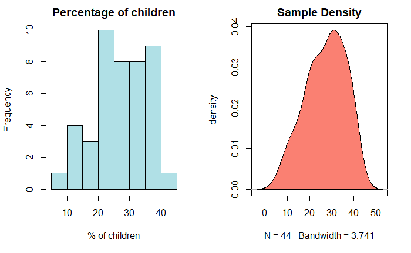

```r
polygon(density(X3),  col = 'salmon')
par(mfrow=c(1,1))
```

```r
par(mfrow=c(1,2))
plot(sort(X3),pch=".", main="Graph of Sorted Data", ylab="Sorted data")
# checking for normality of X1
qqnorm(X3)
```

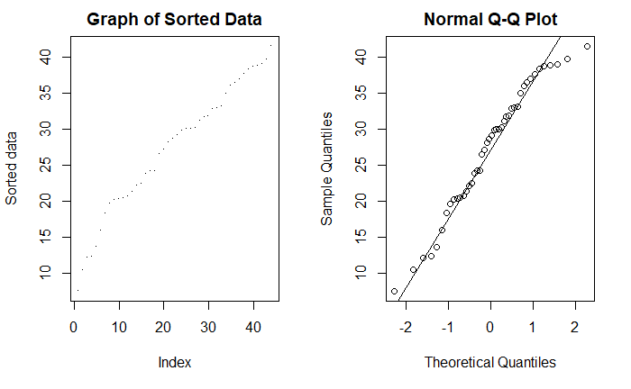

```r
qqline(X3)
# it doesn't seem normal
par(mfrow=c(1,1))
```

```r
par(mfrow=c(2,3))
# X1
hist(X1, main="Histogram of population", ylab="Frequency", xlab="population", prob=TRUE, col ='powderblue')
lines(density(X1),lwd=2) # density
```

```r
# X2
hist(X2, main="Change in Population, in %", ylab="Frequency", xlab="% of change", prob=TRUE, col ='powderblue')
lines(density(X2),lwd=2) # density
```

```r
# X4
hist(X4, main="% of schools that have free lunch", ylab="Frequency", xlab="% schools", prob=TRUE, col ='powderblue')
lines(density(X4),lwd=2) # density
```

```r
# X5
hist(X5, main="Income of household", ylab="Frequency", xlab="% of households", prob=TRUE, col ='powderblue')
lines(density(X5),lwd=2) # density
```

```r
# X6
hist(X6, main="Crime rate", ylab="Frequency", xlab="crime rate", prob=TRUE, col ='powderblue')
lines(density(X6),lwd=2) # density
```

```r
# X7
hist(X7, main="% of change in crime rate", ylab="Frequency", xlab="% of crime rate", prob=TRUE, col ='powderblue')
lines(density(X7),lwd=2) # density
```

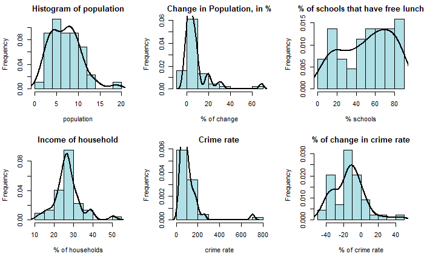

```r
par(mfrow=c(1,1))
```

Pairwise comparison.

[output not shown]

[output cut: 17 more lines]

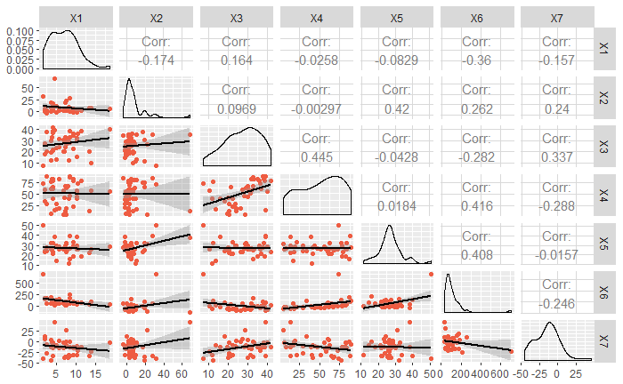

```r
# install.packages('GGally')
library(GGally)
ggpairs(data=mine_data,
        diag = list(continious = wrap("densityDiag", fill = 'powderblue')),
        lower=list(continuous=wrap("smooth", color="tomato2")))
```

Checking Q-Q plot for normality of different variables.

```r
par(mfrow=c(2,3))
qqnorm(X1, main = 'Normal Q-Q plot for X1', col = 'tomato2')
qqline(X1)
```

```r
qqnorm(X2, main = 'Normal Q-Q plot for X2', col = 'turquoise')
qqline(X2)
```

```r
qqnorm(X4, main = 'Normal Q-Q plot for X4', col = 'yellowgreen')
qqline(X4)
```

```r
qqnorm(X5, main = 'Normal Q-Q plot for X5', col = 'dodgerblue')
qqline(X5)
```

```r
qqnorm(X6, main = 'Normal Q-Q plot for X6', col = 'firebrick2')
qqline(X6)
```

```r
qqnorm(X7, main = 'Normal Q-Q plot for X7', col = 'gold2')
qqline(X7)
```

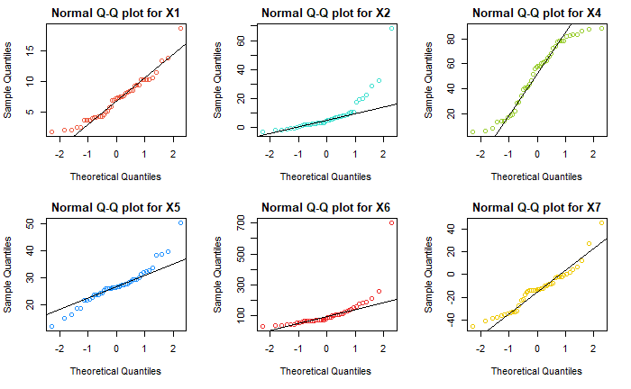

```r
par(mfrow=c(1,1))
```

Linear regression - Trying to see how “% of children” depends of different variables.

Making the first model with all predictors.

```r
model1<-lm(X3~X1+X2+X4+X5+X6+X7,data=mine_data)
summary(model1)
```

```
Call:
lm(formula = X3 ~ X1 + X2 + X4 + X5 + X6 + X7, data = mine_data)

Residuals:
     Min       1Q   Median       3Q      Max
-17.7449  -1.9169   0.6701   3.4736   8.6995

Coefficients:
            Estimate Std. Error t value Pr(>|t|)
(Intercept) 14.16828    4.34887   3.258 0.002408 **
X1           0.18540    0.26407   0.702 0.487019
X2           0.07301    0.07964   0.917 0.365191
X4           0.27444    0.03690   7.437 7.48e-09 ***
X5           0.19094    0.14689   1.300 0.201667
X6          -0.04824    0.01099  -4.390 9.11e-05 ***
X7           0.20554    0.05287   3.888 0.000405 ***
---
Signif. codes:  0 ‘***’ 0.001 ‘**’ 0.01 ‘*’ 0.05 ‘.’ 0.1 ‘ ’ 1

Residual standard error: 5.456 on 37 degrees of freedom
Multiple R-squared:  0.6738,    Adjusted R-squared:  0.6208
F-statistic: 12.74 on 6 and 37 DF,  p-value: 9.549e-08
```

Plotting residuals.

```r
par(mfrow=c(1,2))
plot(rstudent(model1), resid(model1), pch=21, bg='powderblue', cex=1)
qqline(resid(model1))
```

```r
qqnorm(resid(model1))
qqline(resid(model1))
```

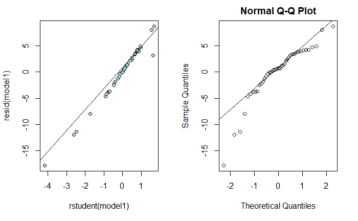

```r
par(mfrow=c(1,1))
```

Checking for the outliers.

```r
# install.packages('car')
library(car)
outlierTest(model1)
```

```
   rstudent unadjusted p-value Bonferonni p
6 -4.175493         0.00018008    0.0079234
```

Checking for influential observations with Cook’s distance.

```r
cook<-cooks.distance(model1)
mine_data[which.max(cook),]
```

|  | X1 | X2 | X3 | X4 | X5 | X6 | X7 |
| --- | --- | --- | --- | --- | --- | --- | --- |
| 7 | 1.7 | 32.2 | 7.5 | 73.8 | 50.5 | 704.1 | -40.9 |

For observation 7 (7th row) the Cook’s distance is the largest.

Making the new model without 7th observation.

```r
data1 <- mine_data[-7,]
attach(data1)
model2 <-lm(X3~X1+X2+X4+X5+X6+X7,data=data1)
summary(model2)
```

```
Call:
lm(formula = X3 ~ X1 + X2 + X4 + X5 + X6 + X7, data = data1)

Residuals:
     Min       1Q   Median       3Q      Max
-16.5350  -1.5307   0.1732   3.2018   7.8970

Coefficients:
            Estimate Std. Error t value Pr(>|t|)
(Intercept) 18.49396    4.98908   3.707 0.000702 ***
X1           0.07234    0.26696   0.271 0.787950
X2           0.06308    0.07806   0.808 0.424340
X4           0.31469    0.04349   7.235 1.62e-08 ***
X5           0.10765    0.15211   0.708 0.483708
X6          -0.08177    0.02292  -3.567 0.001043 **
X7           0.22018    0.05242   4.200 0.000167 ***
---
Signif. codes:  0 ‘***’ 0.001 ‘**’ 0.01 ‘*’ 0.05 ‘.’ 0.1 ‘ ’ 1

Residual standard error: 5.332 on 36 degrees of freedom
Multiple R-squared:  0.6561,    Adjusted R-squared:  0.5988
F-statistic: 11.45 on 6 and 36 DF,  p-value: 3.916e-07
```

Comparing coefficients of two models.

```r
model1$coefficients
```

```
(Intercept)          X1          X2          X4          X5          X6          X7
14.16828041  0.18540071  0.07300968  0.27443962  0.19094225 -0.04824472  0.20553827
```

```r
model2$coefficients
```

```
(Intercept)          X1          X2          X4          X5          X6          X7
18.49395516  0.07234116  0.06307873  0.31468887  0.10764544 -0.08176752  0.22017883
```

We see that coefficients for X1 and X5 changed a lot, which means that observation 7 has significant impact on results, and as it has a large Cook’s distance, it is better to remove this observation from the data.

Checking for assumptions of the residuals for model2.

1. Var(resid) = constant ?

We can see this on the graph of the residuals or using Breusch-Pagan test.

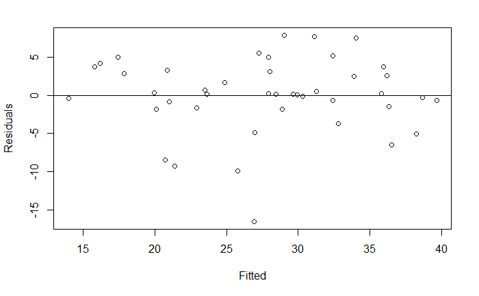

```r
plot(fitted(model2),residuals(model2),xlab="Fitted",ylab="Residuals")
abline(h=0)
```

From the graph it seems like variance of residuals is constant.

```r
# install.packages("lmtest")
library(lmtest)
# Breusch-Pagan test
# H0: Var(resid) = const.
bptest(model2)
```

```
    studentized Breusch-Pagan test

data:  model2
BP = 7.5616, df = 6, p-value = 0.272
```

p-value is big (>0.05) => fail to reject H0 => There is enough evidence to say that variance of residuals is the same for all observations. We confirmed the conclusion from the graph.

2. resid ~ Normal Distribution ?

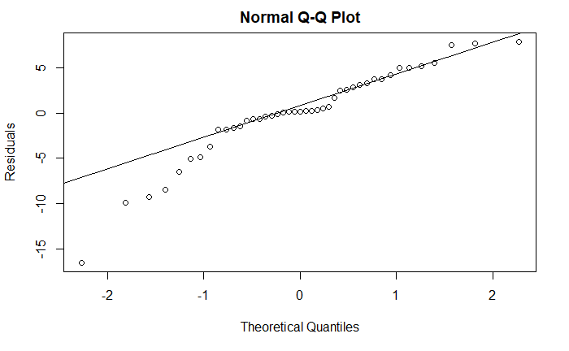

```r
qqnorm(residuals(model2),ylab="Residuals")
qqline(residuals(model2))
```

```r
library(stats)
shapiro.test(residuals(model2))
```

```
    Shapiro-Wilk normality test

data:  residuals(model2)
W = 0.92304, p-value = 0.006765
```

p-value for Shapiro - Wilk’s test is small (<0.05) => reject H0 => Residuals are not normally distributed.

Normality assumption fails => model2 isn’t a good model. We should do transformation of the data. We can try with log transformation.

But, before doing a transformation, we can also look for alternative models (that we can get using step function and AIC value) and check their assumptions.

```r
step(model2)
```

```
Start:  AIC=150.29
X3 ~ X1 + X2 + X4 + X5 + X6 + X7

       Df Sum of Sq    RSS    AIC
- X1    1      2.09 1025.4 148.38
- X5    1     14.24 1037.6 148.89
- X2    1     18.56 1041.9 149.07
<none>              1023.4 150.29
- X6    1    361.73 1385.1 161.31
- X7    1    501.54 1524.9 165.44
- X4    1   1488.09 2511.4 186.90

Step:  AIC=148.38
X3 ~ X2 + X4 + X5 + X6 + X7

       Df Sum of Sq    RSS    AIC
- X5    1     14.62 1040.0 146.99
- X2    1     17.92 1043.3 147.13
<none>              1025.4 148.38
- X6    1    464.85 1490.3 162.46
- X7    1    506.42 1531.8 163.64
- X4    1   1602.30 2627.7 186.84

Step:  AIC=146.99
X3 ~ X2 + X4 + X6 + X7

       Df Sum of Sq    RSS    AIC
- X2    1     31.42 1071.5 146.27
<none>              1040.0 146.99
- X6    1    503.72 1543.8 161.97
- X7    1    512.68 1552.7 162.22
- X4    1   1628.77 2668.8 185.51

Step:  AIC=146.27
X3 ~ X4 + X6 + X7

       Df Sum of Sq    RSS    AIC
<none>              1071.5 146.27
- X6    1    508.85 1580.3 160.98
- X7    1    679.48 1751.0 165.39
- X4    1   1655.38 2726.8 184.44

Call:
lm(formula = X3 ~ X4 + X6 + X7, data = data1)

Coefficients:
(Intercept)           X4           X6           X7
   22.69107      0.32160     -0.08713      0.23713
```

Step function give us the best linear regression model for the data. In this case, that model has only 3 predictors X4, X6 and X7.

```r
model_step <- lm(X3 ~ X4 + X6 + X7, data = data1)
summary(model_step)
```

```
Call:
lm(formula = X3 ~ X4 + X6 + X7, data = data1)

Residuals:
    Min      1Q  Median      3Q     Max
-15.882  -2.132   0.219   3.236  11.093

Coefficients:
            Estimate Std. Error t value Pr(>|t|)
(Intercept) 22.69107    1.90627  11.903 1.48e-14 ***
X4           0.32160    0.04143   7.762 1.97e-09 ***
X6          -0.08713    0.02024  -4.304 0.000109 ***
X7           0.23713    0.04768   4.973 1.36e-05 ***
---
Signif. codes:  0 ‘***’ 0.001 ‘**’ 0.01 ‘*’ 0.05 ‘.’ 0.1 ‘ ’ 1

Residual standard error: 5.242 on 39 degrees of freedom
Multiple R-squared:  0.6399,    Adjusted R-squared:  0.6122
F-statistic:  23.1 on 3 and 39 DF,  p-value: 9.219e-09
```

1. Var(resid) = constant ?

We can see this on the graph of the residuals or using Breusch-Pagan test.

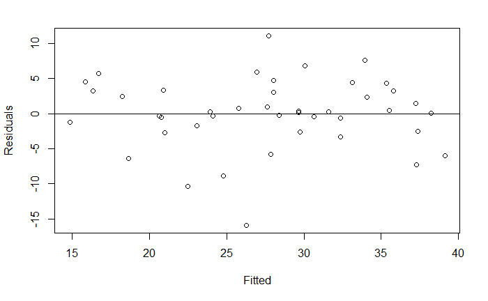

```r
plot(fitted(model_step),residuals(model_step),xlab="Fitted",ylab="Residuals")
abline(h=0)
```

Breusch-Pagan test Ho: Dispersion of the residuals is the same for the all observations

```r
bptest(model_step)
```

```
    studentized Breusch-Pagan test

data:  model_step
BP = 3.0901, df = 3, p-value = 0.3779
```

p-value = 0.3779 > 0.05 => Fail to reject Ho => Dispersion is constant.

2. Normality of the residuals

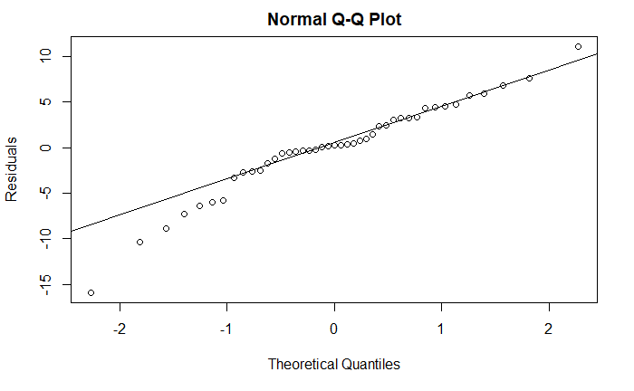

```r
qqnorm(residuals(model_step), ylab = "Residuals")
qqline(residuals(model_step))
```

```r
shapiro.test(residuals(model_step))
```

```
    Shapiro-Wilk normality test

data:  residuals(model_step)
W = 0.95698, p-value = 0.1074
```

p = 0.1074 > 0.05 From the Q-Q plot and Shapiro-Wilk test we see that residuals are normally distributed.

Checking for the correlation of residuals.

```r
par(mfrow=c(1,2))
plot(residuals(model_step), ylab="Residuals")
abline(h=0, lwd=2)
```

```r
cor(residuals(model_step),seq(1:43))
```

```
[1] 0.06288077
```

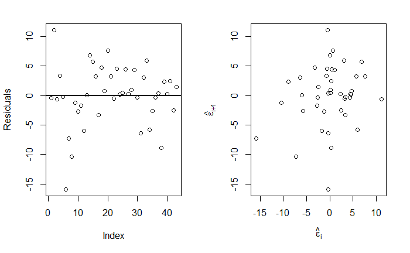

```r
plot(residuals(model_step)[-43], residuals(model_step)[-1], xlab=expression(hat(epsilon)[i]), ylab=expression(hat(epsilon)[i+1]))
```

```r
cor(residuals(model_step)[-1], residuals(model_step)[-43])
```

```
[1] 0.2134223
```

Correlation coefficient is close to 0 => there isn’t correlation.

We can also check correlation using Durbin-Watson test.

```r
dwtest(model_step)
```

```
    Durbin-Watson test

data:  model_step
DW = 1.5715, p-value = 0.07652
alternative hypothesis: true autocorrelation is greater than 0
```

p > 0.05 => Fail to reject Ho => We confirmed that there is no correlation.

“model_step” satisfies all assumptions.

Now we are going to transform the data and make new models.

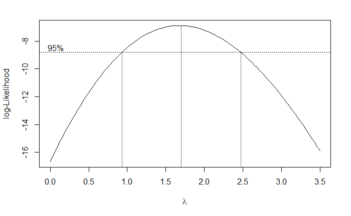

```r
# install.packages("MASS") ]
library(MASS)
boxcox(model2, plotit = T, lambda = seq(0, 3.5, by = 0.5))
```

```r
lambda <- 1.7
y = (X3^lambda - 1)/lambda
boxcoxmodel <- lm(y~X1+X2+X4+X5+X6+X7, data = data1)
summary(boxcoxmodel)
```

```
Call:
lm(formula = y ~ X1 + X2 + X4 + X5 + X6 + X7, data = data1)

Residuals:
     Min       1Q   Median       3Q      Max
-144.365  -17.105    2.135   31.086   88.772

Coefficients:
            Estimate Std. Error t value Pr(>|t|)
(Intercept)  73.5685    47.3981   1.552 0.129377
X1            1.5966     2.5362   0.630 0.532970
X2            1.0167     0.7416   1.371 0.178879
X4            3.1244     0.4132   7.561 6.11e-09 ***
X5            0.8177     1.4451   0.566 0.574995
X6           -0.7418     0.2178  -3.407 0.001632 **
X7            2.1068     0.4980   4.231 0.000153 ***
---
Signif. codes:  0 ‘***’ 0.001 ‘**’ 0.01 ‘*’ 0.05 ‘.’ 0.1 ‘ ’ 1

Residual standard error: 50.65 on 36 degrees of freedom
Multiple R-squared:  0.6836,    Adjusted R-squared:  0.6309
F-statistic: 12.97 on 6 and 36 DF,  p-value: 9.39e-08
```

Alternative models using AIC (Akaik’s Information Criterion) We are looking for a model with the most appropriate independent variables.

```r
step(boxcoxmodel)
```

```
Start:  AIC=343.91
y ~ X1 + X2 + X4 + X5 + X6 + X7

       Df Sum of Sq    RSS    AIC
- X5    1       822  93186 342.29
- X1    1      1017  93381 342.38
<none>               92364 343.91
- X2    1      4822  97187 344.10
- X6    1     29774 122138 353.92
- X7    1     45920 138285 359.26
- X4    1    146688 239052 382.80

Step:  AIC=342.29
y ~ X1 + X2 + X4 + X6 + X7

       Df Sum of Sq    RSS    AIC
- X1    1      1080  94265 340.78
<none>               93186 342.29
- X2    1      6650  99836 343.25
- X6    1     31600 124786 352.85
- X7    1     46463 139649 357.68
- X4    1    148334 241520 381.24

Step:  AIC=340.78
y ~ X2 + X4 + X6 + X7

       Df Sum of Sq    RSS    AIC
<none>               94265 340.78
- X2    1      6403 100668 341.61
- X6    1     44732 138998 355.48
- X7    1     45418 139684 355.70
- X4    1    163540 257806 382.05

Call:
lm(formula = y ~ X2 + X4 + X6 + X7, data = data1)

Coefficients:
(Intercept)           X2           X4           X6           X7
    108.504        1.118        3.200       -0.817        2.060
```

The best model using step function and AIC value is model with X2, X4, X6 and X7 as predictors.

```r
model3 <- lm(y~X2+X4+X6+X7, data = data1)
summary(model3)
```

```
Call:
lm(formula = y ~ X2 + X4 + X6 + X7, data = data1)

Residuals:
     Min       1Q   Median       3Q      Max
-133.694  -19.859    1.437   31.030   85.769

Coefficients:
            Estimate Std. Error t value Pr(>|t|)
(Intercept) 108.5039    19.2588   5.634 1.81e-06 ***
X2            1.1179     0.6958   1.607 0.116429
X4            3.2005     0.3942   8.119 7.95e-10 ***
X6           -0.8170     0.1924  -4.246 0.000135 ***
X7            2.0597     0.4814   4.279 0.000122 ***
---
Signif. codes:  0 ‘***’ 0.001 ‘**’ 0.01 ‘*’ 0.05 ‘.’ 0.1 ‘ ’ 1

Residual standard error: 49.81 on 38 degrees of freedom
Multiple R-squared:  0.6771,    Adjusted R-squared:  0.6431
F-statistic: 19.92 on 4 and 38 DF,  p-value: 6.507e-09
```

We see that X2 isn’t significant so we will remove it from the model.

```r
model4 <- lm(y~X4+X6+X7, data = data1)
summary(model4)
```

```
Call:
lm(formula = y ~ X4 + X6 + X7, data = data1)

Residuals:
    Min      1Q  Median      3Q     Max
-131.40  -26.50   -2.54   30.29  114.32

Coefficients:
            Estimate Std. Error t value Pr(>|t|)
(Intercept) 119.0129    18.4774   6.441 1.27e-07 ***
X4            3.2319     0.4016   8.048 8.17e-10 ***
X6           -0.8231     0.1962  -4.195 0.000152 ***
X7            2.3209     0.4622   5.022 1.17e-05 ***
---
Signif. codes:  0 ‘***’ 0.001 ‘**’ 0.01 ‘*’ 0.05 ‘.’ 0.1 ‘ ’ 1

Residual standard error: 50.81 on 39 degrees of freedom
Multiple R-squared:  0.6552,    Adjusted R-squared:  0.6287
F-statistic:  24.7 on 3 and 39 DF,  p-value: 3.998e-09
```

Now every predictor is significant.

We need to check the assumptions.

1. Is the variance constant?

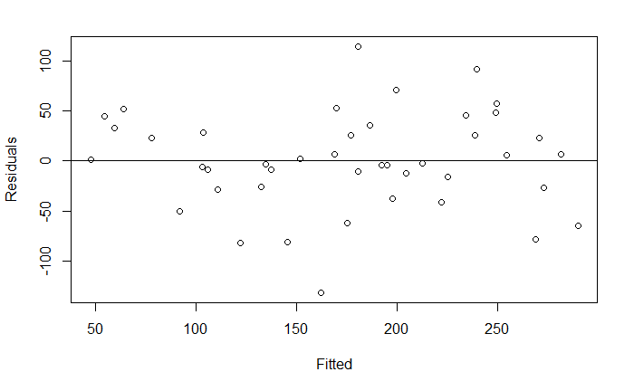

```r
plot(fitted(model4),residuals(model4),xlab="Fitted",ylab="Residuals")
abline(h=0)
```

From the graph we can see that variance is constant.

We can also check this using Breusch-Pagan test. Ho: Dispersion of residuals is constant.

```r
bptest(model4)
```

```
    studentized Breusch-Pagan test

data:  model4
BP = 2.8712, df = 3, p-value = 0.4119
```

p-value is big (>0.05) => fail to reject H0 => There is enough evidence to say that variance of residuals is the same for all observations. We confirmed the conclusion from the graph.

2. resid ~ Normal Distribution ?

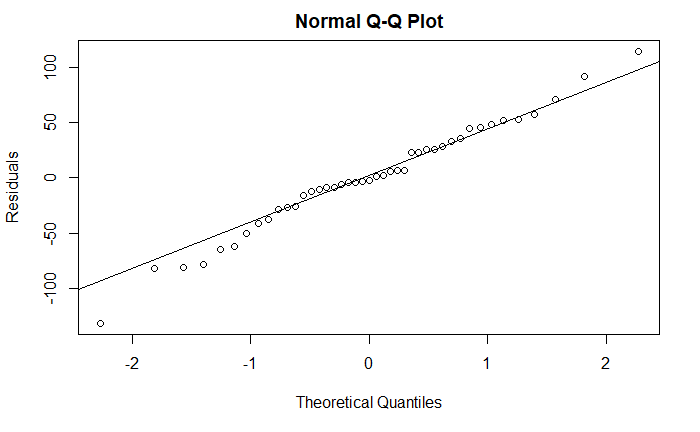

```r
qqnorm(residuals(model4),ylab="Residuals")
qqline(residuals(model4))
```

```r
library(stats)
shapiro.test(residuals(model4))
```

```
    Shapiro-Wilk normality test

data:  residuals(model4)
W = 0.98537, p-value = 0.8507
```

Checking for the correlation of residuals.

```r
par(mfrow=c(1,2))
plot(residuals(model4), ylab="Residuals")
abline(h=0, lwd=2)
```

```r
cor(residuals(model4),seq(1:43))
```

```
[1] 0.05175094
```

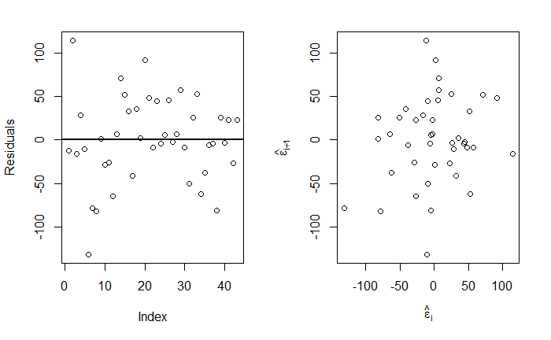

```r
plot(residuals(model4)[-43], residuals(model4)[-1], xlab=expression(hat(epsilon)[i]), ylab=expression(hat(epsilon)[i+1]))
```

```r
cor(residuals(model4)[-1], residuals(model4)[-43])
```

```
[1] 0.1929688
```

Correlation coefficient is close to 0 => there isn’t correlation.

We can also check correlation using Durbin-Watson test.

```r
dwtest(model4)
```

```
    Durbin-Watson test

data:  model4
DW = 1.6088, p-value = 0.09624
alternative hypothesis: true autocorrelation is greater than 0
```

p > 0.05 => Fail to reject Ho => We confirmed that there is no correlation.

model4 satisfies all assumptions.

Because both model_step and model4 satisfied all the assumptions, we can check which model has bigger R-squared value.

```r
summary(model_step)$r.squared
```

```
[1] 0.6399061
```

```r
summary(model4)$r.squared
```

```
[1] 0.6552035
```

model4 has bigger R-squared value => better model is model4.

Making alternative models using adjusted R^2.

First we can try this on the original data, then on the transformed one.

```r
# install.packages("leaps")
library(leaps)
b<-regsubsets(X3~.,data=data1)
(rs <- summary(b))
```

```
Subset selection object
Call: regsubsets.formula(X3 ~ ., data = data1)
6 Variables  (and intercept)
   Forced in Forced out
X1     FALSE      FALSE
X2     FALSE      FALSE
X4     FALSE      FALSE
X5     FALSE      FALSE
X6     FALSE      FALSE
X7     FALSE      FALSE
1 subsets of each size up to 6
Selection Algorithm: exhaustive
         X1  X2  X4  X5  X6  X7
1  ( 1 ) " " " " "*" " " " " " "
2  ( 1 ) " " " " "*" " " " " "*"
3  ( 1 ) " " " " "*" " " "*" "*"
4  ( 1 ) " " "*" "*" " " "*" "*"
5  ( 1 ) " " "*" "*" "*" "*" "*"
6  ( 1 ) "*" "*" "*" "*" "*" "*"
```

```r
rs$adjr2
```

```
[1] 0.2599085 0.4423376 0.6122066 0.6136720 0.6088066 0.5987585
```

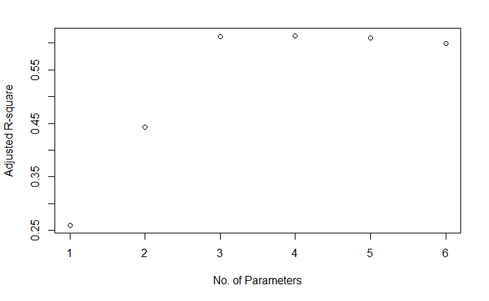

```r
plot(1:6,rs$adjr2,xlab="No. of Parameters",ylab="Adjusted R-square")
```

As the biggest adjusted R^2 is for 4 parameter, we are going to make the model with four parameters.

```r
model5 <- lm(X3 ~ X2 + X4 + X6 + X7, data = data1)
summary(model5)
```

```
Call:
lm(formula = X3 ~ X2 + X4 + X6 + X7, data = data1)

Residuals:
     Min       1Q   Median       3Q      Max
-16.0423  -1.9601   0.4207   3.3388   9.0930

Coefficients:
            Estimate Std. Error t value Pr(>|t|)
(Intercept) 21.95491    2.02293  10.853 3.34e-13 ***
X2           0.07831    0.07309   1.071 0.290741
X4           0.31940    0.04140   7.714 2.71e-09 ***
X6          -0.08670    0.02021  -4.290 0.000118 ***
X7           0.21884    0.05056   4.328 0.000105 ***
---
Signif. codes:  0 ‘***’ 0.001 ‘**’ 0.01 ‘*’ 0.05 ‘.’ 0.1 ‘ ’ 1

Residual standard error: 5.232 on 38 degrees of freedom
Multiple R-squared:  0.6505,    Adjusted R-squared:  0.6137
F-statistic: 17.68 on 4 and 38 DF,  p-value: 2.832e-08
```

We can see that parameter X2 isn’t significant and as model with 3 parameters has adjusted R^2 close to the adjusted R^2 for the model with 4 parameters, we can decide to go with model with 3 parameters.

```r
model6 <- lm(X3 ~ X4 + X6 + X7, data = data1)
summary(model6)
```

```
Call:
lm(formula = X3 ~ X4 + X6 + X7, data = data1)

Residuals:
    Min      1Q  Median      3Q     Max
-15.882  -2.132   0.219   3.236  11.093

Coefficients:
            Estimate Std. Error t value Pr(>|t|)
(Intercept) 22.69107    1.90627  11.903 1.48e-14 ***
X4           0.32160    0.04143   7.762 1.97e-09 ***
X6          -0.08713    0.02024  -4.304 0.000109 ***
X7           0.23713    0.04768   4.973 1.36e-05 ***
---
Signif. codes:  0 ‘***’ 0.001 ‘**’ 0.01 ‘*’ 0.05 ‘.’ 0.1 ‘ ’ 1

Residual standard error: 5.242 on 39 degrees of freedom
Multiple R-squared:  0.6399,    Adjusted R-squared:  0.6122
F-statistic:  23.1 on 3 and 39 DF,  p-value: 9.219e-09
```

Let’s check assumptions for model6.

1. Is the variance constant?

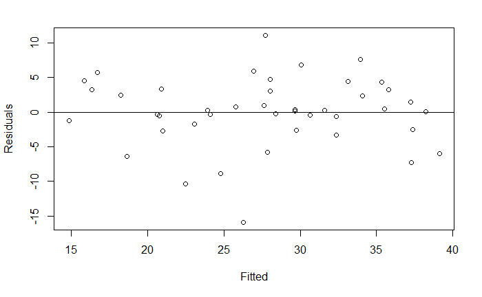

```r
plot(fitted(model6),residuals(model6),xlab="Fitted",ylab="Residuals")
abline(h=0)
```

From the graph we can see that variance is constant.

We can also check this using Breusch-Pagan test. Ho: Dispersion of residuals is constant.

```r
bptest(model6)
```

```
    studentized Breusch-Pagan test

data:  model6
BP = 3.0901, df = 3, p-value = 0.3779
```

p-value is big (>0.05) => fail to reject H0 => There is enough evidence to say that variance of residuals is the same for all observations. We confirmed the conclusion from the graph.

2. resid ~ Normal Distribution ?

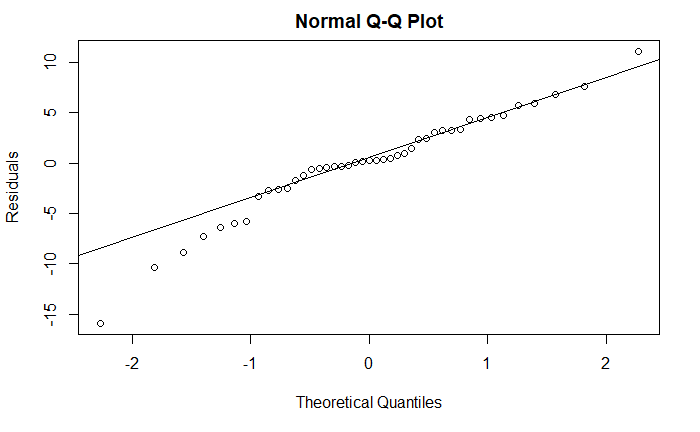

```r
qqnorm(residuals(model6),ylab="Residuals")
qqline(residuals(model6))
```

```r
# library(stats)
shapiro.test(residuals(model6))
```

```
    Shapiro-Wilk normality test

data:  residuals(model6)
W = 0.95698, p-value = 0.1074
```

Checking for the correlation of residuals.

```r
par(mfrow=c(1,2))
plot(residuals(model6), ylab="Residuals")
abline(h=0, lwd=2)
```

```r
cor(residuals(model6),seq(1:43))
```

```
[1] 0.06288077
```

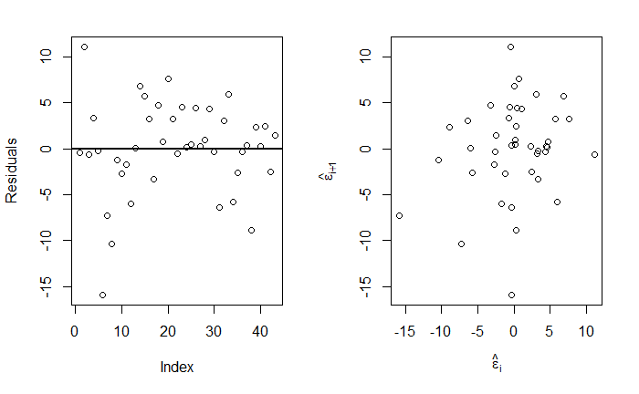

```r
plot(residuals(model6)[-43], residuals(model6)[-1], xlab=expression(hat(epsilon)[i]), ylab=expression(hat(epsilon)[i+1]))
```

```r
cor(residuals(model6)[-1], residuals(model6)[-43])
```

```
[1] 0.2134223
```

Correlation coefficient is close to 0 => there isn’t correlation.

We can also check correlation using Durbin-Watson test.

```r
dwtest(model6)
```

```
    Durbin-Watson test

data:  model6
DW = 1.5715, p-value = 0.07652
alternative hypothesis: true autocorrelation is greater than 0
```

p > 0.05 => Fail to reject Ho => We confirmed that there is no correlation.

model6 satisfies all assumptions.

We have two models that satisfies all assumptions - model4 and model6.

Let’s take a look at those models.

```r
summary(model4)
```

```
Call:
lm(formula = y ~ X4 + X6 + X7, data = data1)

Residuals:
    Min      1Q  Median      3Q     Max
-131.40  -26.50   -2.54   30.29  114.32

Coefficients:
            Estimate Std. Error t value Pr(>|t|)
(Intercept) 119.0129    18.4774   6.441 1.27e-07 ***
X4            3.2319     0.4016   8.048 8.17e-10 ***
X6           -0.8231     0.1962  -4.195 0.000152 ***
X7            2.3209     0.4622   5.022 1.17e-05 ***
---
Signif. codes:  0 ‘***’ 0.001 ‘**’ 0.01 ‘*’ 0.05 ‘.’ 0.1 ‘ ’ 1

Residual standard error: 50.81 on 39 degrees of freedom
Multiple R-squared:  0.6552,    Adjusted R-squared:  0.6287
F-statistic:  24.7 on 3 and 39 DF,  p-value: 3.998e-09
```

```r
summary(model6)
```

```
Call:
lm(formula = X3 ~ X4 + X6 + X7, data = data1)

Residuals:
    Min      1Q  Median      3Q     Max
-15.882  -2.132   0.219   3.236  11.093

Coefficients:
            Estimate Std. Error t value Pr(>|t|)
(Intercept) 22.69107    1.90627  11.903 1.48e-14 ***
X4           0.32160    0.04143   7.762 1.97e-09 ***
X6          -0.08713    0.02024  -4.304 0.000109 ***
X7           0.23713    0.04768   4.973 1.36e-05 ***
---
Signif. codes:  0 ‘***’ 0.001 ‘**’ 0.01 ‘*’ 0.05 ‘.’ 0.1 ‘ ’ 1

Residual standard error: 5.242 on 39 degrees of freedom
Multiple R-squared:  0.6399,    Adjusted R-squared:  0.6122
F-statistic:  23.1 on 3 and 39 DF,  p-value: 9.219e-09
```

Both models have the same independent variables, but model4 is on the transformed data.

R^2 is bigger for model4 so this is the best model.

The best model is y ~ X4 + X6 + X7.

If we want to predict population of children (in percentage) in different parts of Denver we should use the model with transformed data and with next three predictors: percentage of schools that have free lunch, crime rate and percentage of changes in crime rate.